# A3: SPL Library Checkouts

### Introduction

The dataset, named “checkout_data”, is compiled from checkouts at the Seattle Public Library made between the years 2017 and 2023. I decided to look at the number of checkouts each year for the material type, and for whether the item they were checking out was physical or digital. I also decided to look at the top material types that were checked out between those years, in comparison to the more popular books and ebooks. I thought that it would shed a lot of light on the importance of the data to analyze the mediums and material types that these items were checked out as. This is because by looking at these we can tell which of these mediums and types are most popular, which can effect what the library may have in stock.

### The Dataset

- Who collected/published the data?
  - The data was collected by the Seattle Public Library, and also published by them too.
- What are the parameters of the data (dates, number of checkouts, kinds of books, etc.)?
  - The data collected and published has 42 million rows, and 12 columns. These are: UsageClass, CheckoutType, MaterialType, CheckoutYear, CheckoutMonth, Number of Checkouts, Title, ISBN, Creator, Subjects, Publisher, and PublicationYear. The data also includes a large variety of book genres, and some of the books are classified as multiple types.
- How was the data collected or generated?
  - The data collected was based on books that were at least checked out 10 times in a single month. These books were then added to the dataset between the years 2017 to 2023.
- Why was the data collected?
  - The data was collected to show the more popular books of months and years between the time period, and other information about those books that may influence why.
- What, if any, ethical questions do you need to consider when working with this data?
  - In terms of ethics, there’s nothing harmful about the dataset.
- What are possible limitations or problems with this data?
  - There are a few limitations about the data, one is that the data has information for the year 2023, which is an incomplete year since the year has not come to a close. Another, is that the data only looks at the books with 10 checkouts or more within a month. This means that the viewer of the dataset cannot look at the books with the least amount of checkouts, which would be those with less than 10 checkouts. A third limitation is that it only looks at those with 10 checkouts within a month, but not those that have 10 checkouts outside of that constraint. A fourth limitation is that the data itself is incomplete in some areas, some of the items checked out do not have an ISBN or Creator, which will impact any speculation made by any others who decide to inspect the dataset.

### First Trends Over Time Chart

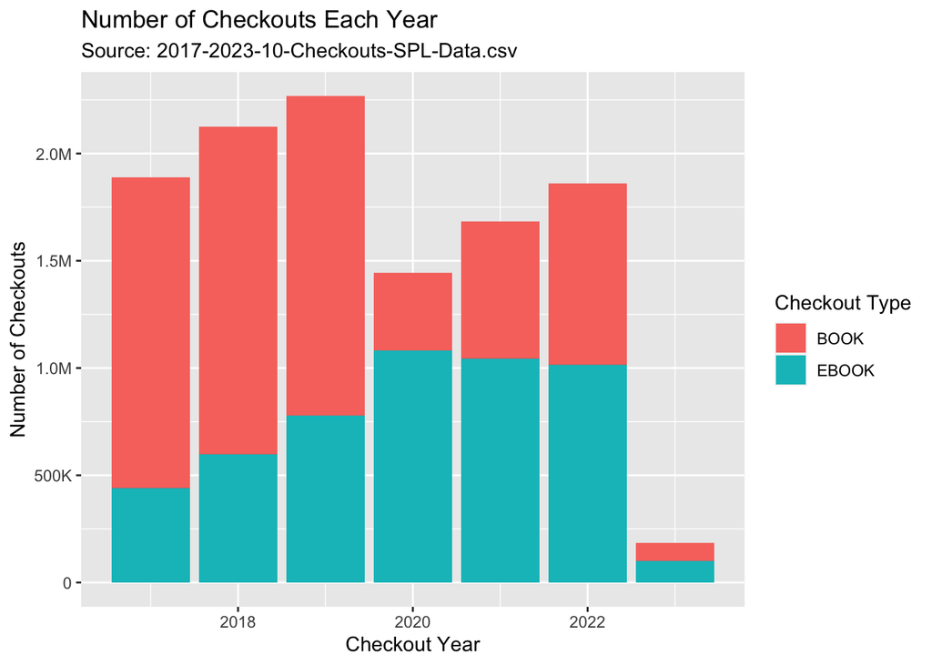

- I made this chart to show this chart to show which of the checkout types were the most most popular the books, which, after completing the chart, I found that books were more frequently checked out over ebooks.

### Second Trends Over Time Chart

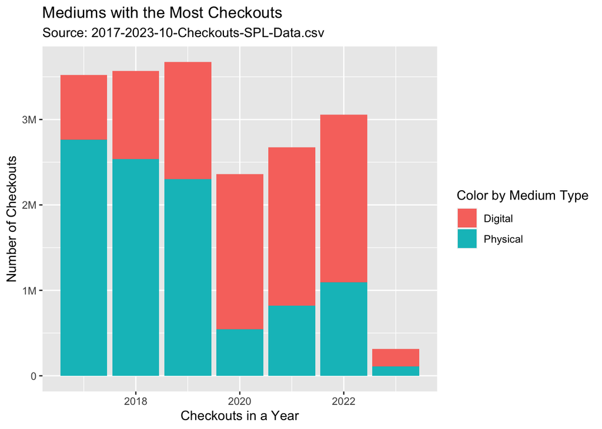

### Custom Chart

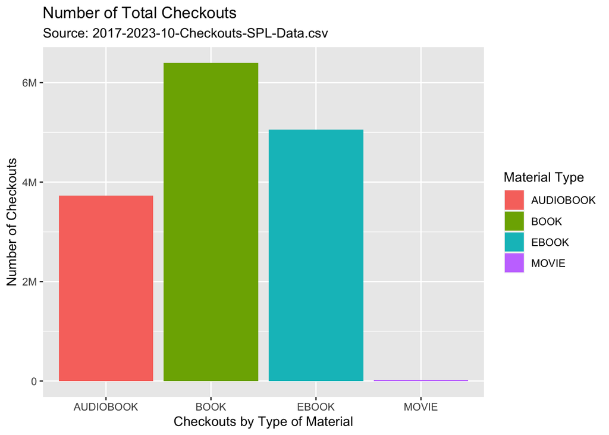

- I made this chart because I was more curious about the martial types that get checked out. I decided to use 4 of the most popular ones (that I personally thought were frequently checked out) and found out that the movies hardly get checked out (much to my surprise). I also was able to get a more accurate look at the total checkouts over the entire time frame. I also discovered that the books have over a million more checkouts than ebooks.